# sample-matching_IPUMS-NQ_BR

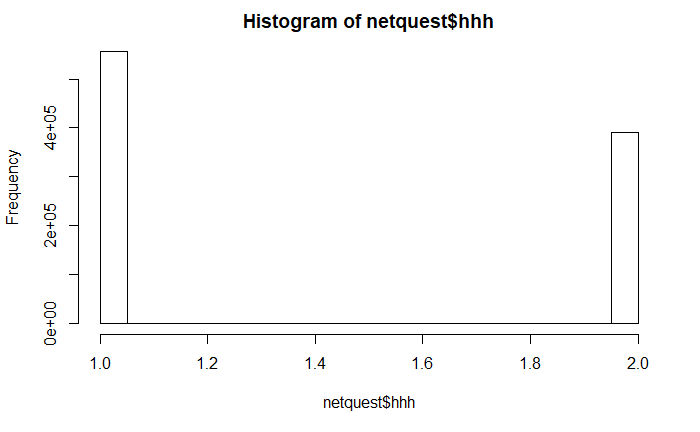

```r
hist(netquest$hhh)
```

Give ID to both datasets, so we can go back to IDs when necessary

```r
census$id <- seq(dim(census)[1])
netquest$id <- seq(dim(netquest)[1])
```

Create the sample and panel from this:

If we do some non-numeric matching, we’d want to adjust the labels/levels.

```r
panel <- to_factor(netquest[append(matching.vars, c('id'))],
                   drop_unused_labels = TRUE)
panel['Fakeid'] <- netquest[[NQ_id]]
panel <- panel[panel$age>17,]
panel <- na.omit(panel)
summary(panel)
```

```
      gend            age               ed              emp             auto           nbath             pc            fridg           washer          child            radio             tv            marst
 Min.   :1.000   Min.   : 18.00   Min.   : 1.000   Min.   :1.000   Min.   :1.000   Min.   :1.000   Min.   :1.000   Min.   :1.000   Min.   :1.000   Min.   :0.0000   Min.   :1.000   Min.   :1.000   Min.   :1.00
 1st Qu.:1.000   1st Qu.: 23.00   1st Qu.: 7.000   1st Qu.:2.000   1st Qu.:1.000   1st Qu.:1.000   1st Qu.:1.000   1st Qu.:1.000   1st Qu.:1.000   1st Qu.:0.0000   1st Qu.:1.000   1st Qu.:1.000   1st Qu.:1.00
 Median :1.000   Median : 29.00   Median : 7.000   Median :2.000   Median :1.000   Median :1.000   Median :1.000   Median :1.000   Median :1.000   Median :0.0000   Median :1.000   Median :1.000   Median :2.00
 Mean   :1.493   Mean   : 31.16   Mean   : 7.317   Mean   :2.341   Mean   :1.416   Mean   :1.005   Mean   :1.271   Mean   :1.013   Mean   :1.174   Mean   :0.8395   Mean   :1.431   Mean   :1.046   Mean   :2.49
 3rd Qu.:2.000   3rd Qu.: 37.00   3rd Qu.: 8.000   3rd Qu.:3.000   3rd Qu.:2.000   3rd Qu.:1.000   3rd Qu.:2.000   3rd Qu.:1.000   3rd Qu.:1.000   3rd Qu.:1.0000   3rd Qu.:2.000   3rd Qu.:1.000   3rd Qu.:4.00
 Max.   :2.000   Max.   :100.00   Max.   :12.000   Max.   :4.000   Max.   :2.000   Max.   :2.000   Max.   :2.000   Max.   :2.000   Max.   :2.000   Max.   :7.0000   Max.   :2.000   Max.   :2.000   Max.   :4.00

      pern            hhtype           hhh             X                Y                 id                      Fakeid
 Min.   : 1.000   Min.   :0.000   Min.   :1.00   Min.   :-73.37   Min.   :-33.135   Min.   :     1   0000161dba554c59:     1
 1st Qu.: 2.000   1st Qu.:2.000   1st Qu.:1.00   1st Qu.:-49.11   1st Qu.:-23.650   1st Qu.:236697   000028a7d0ad6417:     1
 Median : 3.000   Median :4.000   Median :1.00   Median :-46.65   Median :-22.783   Median :473040   0000370bd1c9df20:     1
 Mean   : 3.538   Mean   :3.531   Mean   :1.37   Mean   :-46.27   Mean   :-19.711   Mean   :473638   00005608f0cf35bd:     1
 3rd Qu.: 4.000   3rd Qu.:5.000   3rd Qu.:2.00   3rd Qu.:-43.45   3rd Qu.:-16.609   3rd Qu.:710540   000066307b765519:     1
 Max.   :15.000   Max.   :6.000   Max.   :2.00   Max.   :-34.85   Max.   :  4.263   Max.   :947524   000079b5a8742202:     1
                                                                                                     (Other)         :314838
```

ADJUST FOR COUNTRY!

```r
census.proc <- to_factor(census[append(matching.vars,c(
  strat2,
  'PERWT',
  strat1,'id'))], drop_unused_labels = TRUE)
census.proc <- census.proc[census.proc$age>17,]
census.proc <- na.omit(census.proc)
census.proc <- census.proc[order(census.proc[strat1],census.proc[strat2]),]
summary(census.proc)
```

```
      gend            age               ed              emp             auto           nbath             pc            fridg          washer          child           radio             tv            marst
 Min.   :1.000   Min.   : 18.00   Min.   : 1.000   Min.   :1.000   Min.   :1.000   Min.   :1.000   Min.   :1.000   Min.   :1.00   Min.   :1.000   Min.   :0.000   Min.   :1.000   Min.   :1.000   Min.   :1.000
 1st Qu.:1.000   1st Qu.: 27.00   1st Qu.: 3.000   1st Qu.:2.000   1st Qu.:1.000   1st Qu.:1.000   1st Qu.:1.000   1st Qu.:1.00   1st Qu.:1.000   1st Qu.:0.000   1st Qu.:1.000   1st Qu.:1.000   1st Qu.:2.000
 Median :2.000   Median : 39.00   Median : 5.000   Median :2.000   Median :2.000   Median :1.000   Median :2.000   Median :1.00   Median :2.000   Median :1.000   Median :1.000   Median :1.000   Median :4.000
 Mean   :1.511   Mean   : 41.35   Mean   : 4.932   Mean   :2.611   Mean   :1.604   Mean   :1.081   Mean   :1.654   Mean   :1.07   Mean   :1.588   Mean   :1.073   Mean   :1.183   Mean   :1.054   Mean   :3.072
 3rd Qu.:2.000   3rd Qu.: 53.00   3rd Qu.: 7.000   3rd Qu.:4.000   3rd Qu.:2.000   3rd Qu.:1.000   3rd Qu.:2.000   3rd Qu.:1.00   3rd Qu.:2.000   3rd Qu.:2.000   3rd Qu.:1.000   3rd Qu.:1.000   3rd Qu.:4.000
 Max.   :2.000   Max.   :100.00   Max.   :12.000   Max.   :4.000   Max.   :2.000   Max.   :2.000   Max.   :2.000   Max.   :2.00   Max.   :2.000   Max.   :7.000   Max.   :2.000   Max.   :2.000   Max.   :4.000
      pern            hhtype           hhh              X                Y               URBAN          PERWT         GEO1_BR2010         id
 Min.   : 1.000   Min.   :0.000   Min.   :1.000   Min.   :-73.37   Min.   :-33.135   Min.   :1.00   Min.   :  2.13   Min.   :11.0   Min.   :      1
 1st Qu.: 3.000   1st Qu.:4.000   1st Qu.:1.000   1st Qu.:-49.72   1st Qu.:-23.401   1st Qu.:2.00   1st Qu.: 10.09   1st Qu.:26.0   1st Qu.:2605180
 Median : 4.000   Median :4.000   Median :2.000   Median :-46.50   Median :-20.028   Median :2.00   Median : 18.55   Median :32.0   Median :5041337
 Mean   : 3.918   Mean   :3.857   Mean   :1.574   Mean   :-45.92   Mean   :-17.190   Mean   :1.78   Mean   : 19.98   Mean   :32.5   Mean   :4970993
 3rd Qu.: 5.000   3rd Qu.:5.000   3rd Qu.:2.000   3rd Qu.:-41.62   3rd Qu.: -9.426   3rd Qu.:2.00   3rd Qu.: 24.97   3rd Qu.:41.0   3rd Qu.:7343671
 Max.   :50.000   Max.   :6.000   Max.   :2.000   Max.   :-34.85   Max.   :  4.263   Max.   :2.00   Max.   :225.10   Max.   :53.0   Max.   :9693058
```

sample! Stratified by urban/rural and by region, weighted !REMEMBER TO MATCH THE SEED!

```r
n <- 1200
set.seed(111)
strats=c(strat1,strat2)
library(sampleMatch)
target  <- strat_weight_sample(census.proc,strats,'PERWT',n)
```

```
PERWT ~ GEO1_BR2010 + URBAN
<environment: 0x00000248dcb6c898>
```

```r
#add Fakeid, so we can keep those from the panel in the matching set
target['Fakeid'] <- as.integer(rep(999999, length(target$age)))
```

Making sure this stratification worked…

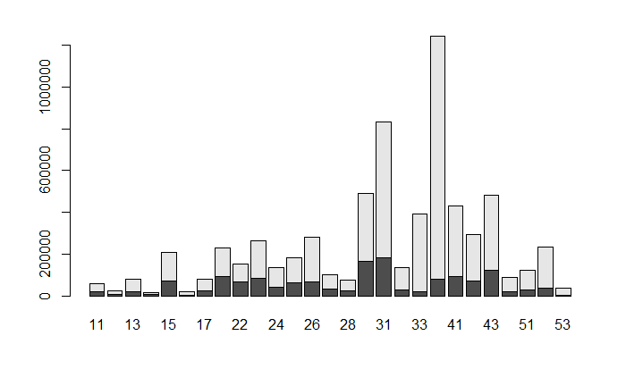

```r
barplot(table(census.proc[[strat2]], census.proc[[strat1]]))
```

Add a treatment into it:

```r
panel['treat'] <- rep(0,length(panel$age))
target['treat'] <- rep(1,length(target$age))
```

Now join this data together:

```r
levels(panel$Fakeid) <- c(levels(panel$Fakeid),999999) #to make room for the non-existent Fakeid
alldata<-rbind(panel,target[names(panel)])
#jointId will be the sequence number in the joint dataframe -- MAY NOT NEED THIS?
alldata$jointId <- seq(dim(alldata)[1])
rownames(alldata) <- alldata$jointId
unique(table(alldata$id))
```

```
[1] 1 2
```

Divide target sample into age quantiles (in this case, deciles) and add that to the data:

```r
age_q <- quantile(target$age,prob = seq(0,1,0.1))
alldata['age_group'] <- as.integer(cut(alldata$age,breaks = age_q, include.lowest = TRUE))
alldata$age_group[is.na(alldata$age_group)] <- 10
```

# for the methods that require numeric approximation

```r
alldata_num<-data.frame(lapply(alldata, as.numeric))
```

```r
summary(alldata_num)
```

```
      gend            age              ed              emp             auto           nbath             pc            fridg           washer          child          radio            tv            marst
 Min.   :1.000   Min.   : 18.0   Min.   : 1.000   Min.   :1.000   Min.   :1.000   Min.   :1.000   Min.   :1.000   Min.   :1.000   Min.   :1.000   Min.   :0.00   Min.   :1.00   Min.   :1.000   Min.   :1.000
 1st Qu.:1.000   1st Qu.: 23.0   1st Qu.: 7.000   1st Qu.:2.000   1st Qu.:1.000   1st Qu.:1.000   1st Qu.:1.000   1st Qu.:1.000   1st Qu.:1.000   1st Qu.:0.00   1st Qu.:1.00   1st Qu.:1.000   1st Qu.:1.000
 Median :1.000   Median : 29.0   Median : 7.000   Median :2.000   Median :1.000   Median :1.000   Median :1.000   Median :1.000   Median :1.000   Median :0.00   Median :1.00   Median :1.000   Median :2.000
 Mean   :1.493   Mean   : 31.2   Mean   : 7.309   Mean   :2.342   Mean   :1.416   Mean   :1.005   Mean   :1.272   Mean   :1.013   Mean   :1.176   Mean   :0.84   Mean   :1.43   Mean   :1.046   Mean   :2.492
 3rd Qu.:2.000   3rd Qu.: 37.0   3rd Qu.: 8.000   3rd Qu.:3.000   3rd Qu.:2.000   3rd Qu.:1.000   3rd Qu.:2.000   3rd Qu.:1.000   3rd Qu.:1.000   3rd Qu.:1.00   3rd Qu.:2.00   3rd Qu.:1.000   3rd Qu.:4.000
 Max.   :2.000   Max.   :100.0   Max.   :12.000   Max.   :4.000   Max.   :2.000   Max.   :2.000   Max.   :2.000   Max.   :2.000   Max.   :2.000   Max.   :7.00   Max.   :2.00   Max.   :2.000   Max.   :4.000
      pern            hhtype           hhh              X                Y                 id              Fakeid           treat             jointId         age_group
 Min.   : 1.000   Min.   :0.000   Min.   :1.000   Min.   :-73.37   Min.   :-33.135   Min.   :      1   Min.   :     1   Min.   :0.000000   Min.   :     1   Min.   : 1.000
 1st Qu.: 2.000   1st Qu.:2.000   1st Qu.:1.000   1st Qu.:-49.11   1st Qu.:-23.650   1st Qu.: 237535   1st Qu.:237636   1st Qu.:0.000000   1st Qu.: 79011   1st Qu.: 2.000
 Median : 3.000   Median :4.000   Median :1.000   Median :-46.65   Median :-22.775   Median : 474621   Median :474784   Median :0.000000   Median :158022   Median : 4.000
 Mean   : 3.539   Mean   :3.532   Mean   :1.371   Mean   :-46.26   Mean   :-19.702   Mean   : 490987   Mean   :475434   Mean   :0.003791   Mean   :158022   Mean   : 3.861
 3rd Qu.: 4.000   3rd Qu.:5.000   3rd Qu.:2.000   3rd Qu.:-43.45   3rd Qu.:-16.514   3rd Qu.: 712980   3rd Qu.:713235   3rd Qu.:0.000000   3rd Qu.:237032   3rd Qu.: 6.000
 Max.   :20.000   Max.   :6.000   Max.   :2.000   Max.   :-34.85   Max.   :  4.263   Max.   :9689997   Max.   :947532   Max.   :1.000000   Max.   :316042   Max.   :10.000
```

Now the matching begins. This is using the MatchIt package as we are used to…

```r
matching.form <- as.formula(paste0("treat ~ ", paste(matching.vars, collapse=' + ')))
```

We’ll have to repeat this process (at least for everything except PS), since the memory can’t deal with all of this. * start empty dataframe initialized with target IDs * make a copy of the data to alter * for each i in range: + run the matching + store the matched IDs + store some overall metrics about the match + reduce the panel data * return the match objects

```r
matchRatio <- function(data, metric, n, exact = c()){

  # assign the dataframe to hold the matching results
  df <- data.frame(matrix(ncol=1, nrow=sum(data$treat==1)))
  names(df) <- c("targetId")
  df$targetId <- data$id[data$treat==1]

  # assign the object to hold all the matching information
  matches <- vector("list",n)

  # make a copy of the passed-in data
  data.copy <- data.frame(data)


  # loop over the number of respondents per target
  # if there are issues, can I relax the age groups?
  for(i in 1:n){
    print(paste('i = ',to_character(i)))
    m <- matchit(matching.form,
                 data = data.copy, exact=exact, method = "nearest", distance = metric)

    try({matches[[i]] <- m
        targetids <- data.copy[row.names(m$match.matrix), "id"]
        panelids <- as.data.frame(data.copy[m$match.matrix,"Fakeid"])
        names(panelids)<-c("panelId")
        panelids['targetId']<-targetids
        df <- merge(x=df, y=panelids, by="targetId", all.x = TRUE, suffixes=c("",to_character(i)))
        } #... maybe merge instead might be safer?
    )

    controls <- match.data(m, group='control')
    data.copy <- data.copy[!data.copy$jointId %in% controls$jointId,] # not relying on rownames

  }
  return(list("ids"=df, "matches"=matches))
}
```

```r
matches.cem_mah = matchRatio(alldata_num, "mahalanobis", 1, exact = c("age_group","gend"))
```

```
[1] "i =  1"
```

Save the id’s of the matches to a file, so I don’t lose them–just in case

```r
tmp <- matches.cem_mah$ids
# attaching NQ panel code
tmp[NQ_id] <- merge(x = matches.cem_mah$ids,
                    y = alldata[alldata$treat==0, c("Fakeid",'id')],
                    by.x = "panelId",
                    by.y = "id")[["Fakeid"]]
# attaching census identification, just in case!
tmp[c("SERIAL","PERNUM")] <- merge(x = matches.cem_mah$ids,
                                   y = census[c("SERIAL","PERNUM","id")],
                                   by.x = 'targetId',
                                   by.y = 'id')[c("SERIAL","PERNUM")]
write.csv(x=tmp[c("targetId",NQ_id, "SERIAL","PERNUM")], file=paste0("C:/Users/schadem/Box Sync/LAPOP Shared/working documents/maita/Coordination/IDB Online/Matching process/Data/",country,"/panel/matches_cem-mah.csv"))
```

```r
summary(tmp)
```

```
    targetId          panelId                  gp_codigo        SERIAL              PERNUM
 Min.   :   2126   Min.   :  1345   004b8581dfc30412:   1   Min.   :6.590e+05   Min.   : 1.000
 1st Qu.:2775248   1st Qu.:216803   0073737a8bf0f306:   1   1st Qu.:7.415e+08   1st Qu.: 1.000
 Median :5369950   Median :450563   00f7a3ab5a36181c:   1   Median :1.524e+09   Median : 2.000
 Mean   :5050460   Mean   :457296   00f99f3646a04751:   1   Mean   :1.452e+09   Mean   : 2.314
 3rd Qu.:7184562   3rd Qu.:697116   01021a5a44db5036:   1   3rd Qu.:2.103e+09   3rd Qu.: 3.000
 Max.   :9689997   Max.   :941344   015632cdb9348df3:   1   Max.   :2.906e+09   Max.   :12.000
                                    (Other)         :1192
```